# GCDS Homework #05

KEY

Due: 10-06-2022

For this homework, you will save the `R Markdown` homework document and save it to “GCDS/r” on your computer. Rename as **“GCDS_HW_05_yourname”**. When you open it, add your name to the author part of the YAML code. The homework will need to be submitted as a `knit` HTML file. Feel free to work with a partner but understand that the work submitted has to be your own.

This homework assignment is focused on 5 of the 6 main verb functions from `dplyr` for data manipulation:

- `select()`: for selecting variables
- `mutate()`: for creating/modifying/converting variables
- `filter()`: for filtering cases/rows
- `group_by()`: for grouping by variable levels
- `summarize()` or `summarise()`: for summarizing statistics

`arrange()` is for arranging the data frame by variable(s) but this won’t affect summarizing so, we won’t make a big deal about that now.

*NOTE: This homework will serve to prepare you to deal with some data used later in the class. These questions are designed specifically to help you practice using functions but also to help you work through steps you will apply to later projects using almost identical data.*

I held out as long as I could before posting this homework, hoping that more responses would come so that it would make more sense for your final project. Unfortunately, since the posting on 9/16 about half of the class/teams yet to complete the general survey so these data are incomplete and another file will need to be downloaded and retrieved at some poin the future. You will have to keep this in mind so that your final project uses the full data set.

What does the data limitation mean for this homework assignment? You will see that the exact game categories, design, mechanics, etc. are not reflected by their variable names but only vaguely by their grouping as exported from the survey software. As part of data science is cleaning up data; even surveys need to be cleaned up. I planned to do this as a courtesy but the low response rate even from enrolled students suggests this isn’t a priority. Unfortunately, answering this week’s questions come with a fair amount of ambiguity but if you are curious, you can clean up your variables by reviewing pdf of the survey available in Slack #data named “GCDS22_Qualtrics_Survey.pdf”. There is also a file in #data named “General_Survey_var_names.csv” that will help you understand the variables and questions.

**Questions:**

If you collaborated with any peers, add their names here:

# 1 **Load Libraries**

Load the necessary libraries to read in, manipulate, and plot data.

```r
library(readr)
library(dplyr)
```

```r
library(ggplot2)
```

# 2 **Read Data**

The current responses to the General Survey are in a data file named “General_Survey.csv”. You should read in the file and save as a data frame object named `GENERAL`.

Completed: 1001 1002 1003 1004 1101 1102 1103 1104 1501 1502 1503 1504 1703 1705 1706 1901 1902 1903 1904 1905 2001 2002 2003

```r
dat_file_path <- paste(data_dir, "General_Survey.csv", sep = "/")

GENERAL <- readr::read_csv(dat_file_path)
```

# 3 **Cleaning up your 99s**

Of course, you might be curious who did not answer certain questions, for which a `99` would be present in the data. However, for certain plots involving any sums, means, etc., the `99` will influence your plot to an extent it doesn’t make sense. Keep in mind, you will not typically be tipped off to fix such problems as the data scientist needs to look at the data to understand it and ask questions if they are uncertain.

At some point you might need to make all `99`s into `NA`s before moving forward.

```r
GENERAL <- GENERAL %>%
  mutate(., across(everything(), ~na_if(.x, 99)))
```

# 4 **Histogram or Density Plot**

## 4.1 *Histogram 1: One varaiable, One color*

Create either a `geom_histogram()` or `geom_density()` for a numeric variable of interest.

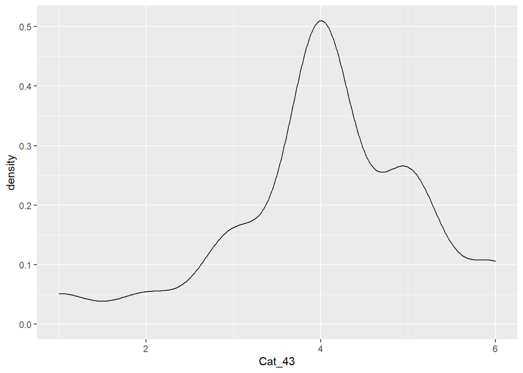

```r
GENERAL %>% ggplot(.) +
  geom_density(aes(Cat_43))
```

## 4.2 *Histogram 2: One varaiable, n colors*

Create either a `geom_histogram()` or `geom_density()` for a numeric variable that visualizes a separate histogram for the `Gender` variable on the same plot.

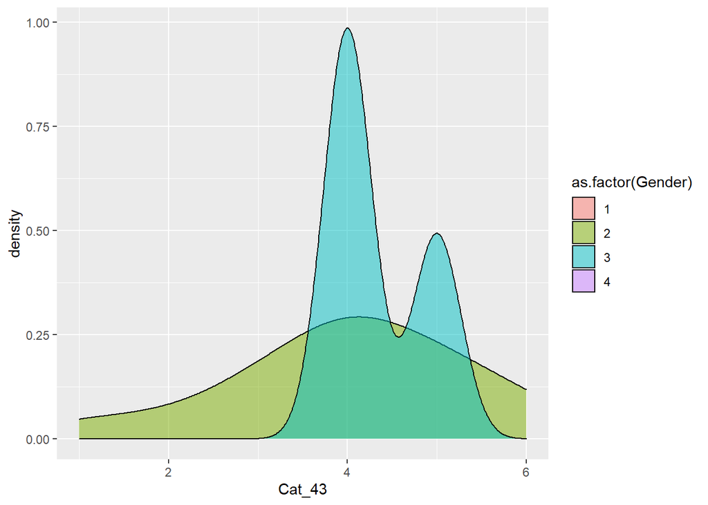

```r
GENERAL %>% ggplot(.) +
  geom_density(mapping = aes(x = Cat_43,
                             fill = as.factor(Gender)),
               alpha = .5)
```

# 5 **Bar Plot**

## 5.1 *Bar Plot 1: One variable*

Create a `geom_bar()` to visualize the variable in the data set that represented the most pleasurable reason to play board games.

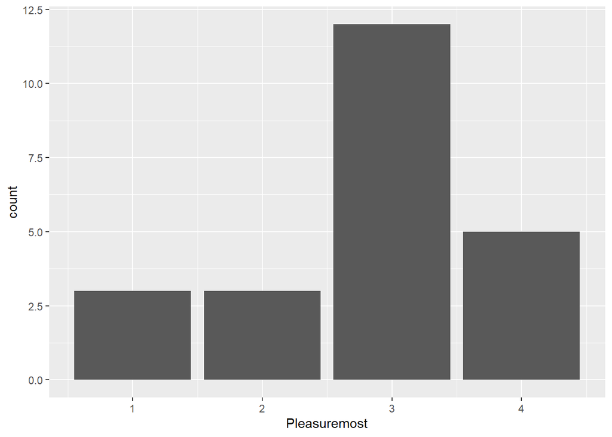

```r
GENERAL %>%
  ggplot() +
  geom_bar(data = GENERAL,
           mapping = aes(x = Pleasuremost))
```

## 5.2 *Bar Plot 2: One variable, One color*

Do the same for board game play `Frequency` but this time plot so that the counts are on the x axis.

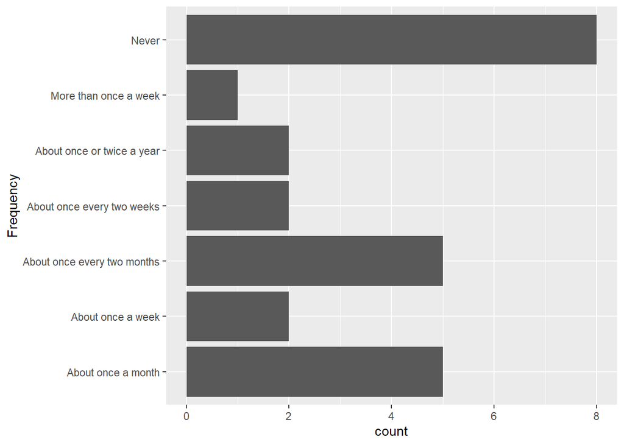

```r
ggplot() +
  geom_bar(data = GENERAL,
           mapping = aes(x = Frequency)
           ) +
  coord_flip()
```

## 5.3 *Bar Plot 3: Bars colors by gender*

Create the same bar plot but modify your aesthetics to fill the bar with colors for `Gender` groups.

1 = Male 2 = Female 3 = Non-binary 4 = Other 5 = Prefer not to say NA = Didn’t answer

Remember that data need to take a position in visual space and by default, the position of data was their ‘identity’. Because all genders answered the same question about play frequency, by default the bars for both groups will take the same position on the plot for each frequency response option. As a result, you will end up with a *stacked bar plot*. Sometimes, you want stacked bars but for this instance, you want to quickly determine whether the counts vary as a function of gender.

Pro tip, to make the bars not take the same position, add `position = "dodge"` to your function so that they bars will take a dodge position.

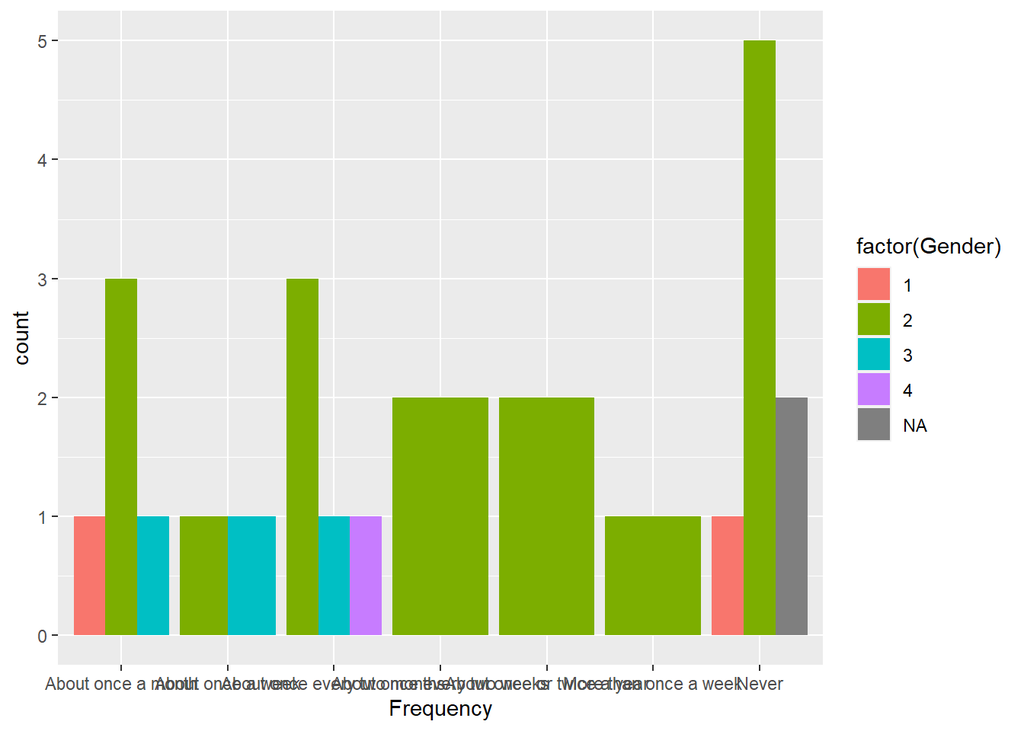

```r
ggplot() +
  geom_bar(data = GENERAL,
           mapping = aes(x = Frequency,
                         fill = factor(Gender)),
           position = "dodge") #+
```

```r
#  coord_flip()
```

# 6 **Column Plot**

## 6.1 *Column Plot 1: Single Plot*

Chose one of your game categories (e.g,. CAT_) or mechanics (e.g., Mech_) to pair with Gender for a column plot. Determine whether you find differences in ratings.

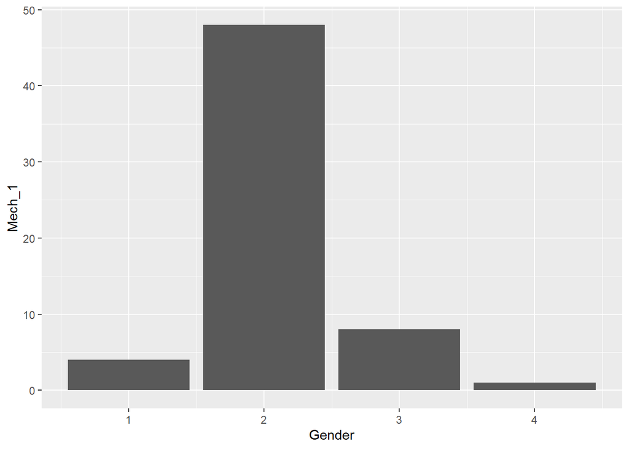

```r
GENERAL %>%
  ggplot(.,
         mapping = aes(x = Gender,
                       y = Mech_1)) +
  geom_col()
```

## 6.2 *Column Plot 2: Plot With Aesthetics*

Take the same variables but change the bar color to vary with Gender

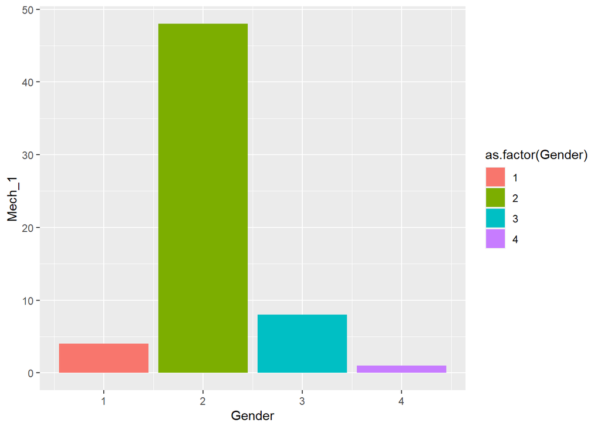

```r
GENERAL %>%
  ggplot(.,
         mapping = aes(x = Gender,
                       y = Mech_1,
                       fill = as.factor(Gender))) +
  geom_col()
```

# 7 **Point Plot**

Take two column variables that have the fewest `NA`s and create a point-plot geom. You can practice adding aesthetics if you want some practice for your projects.

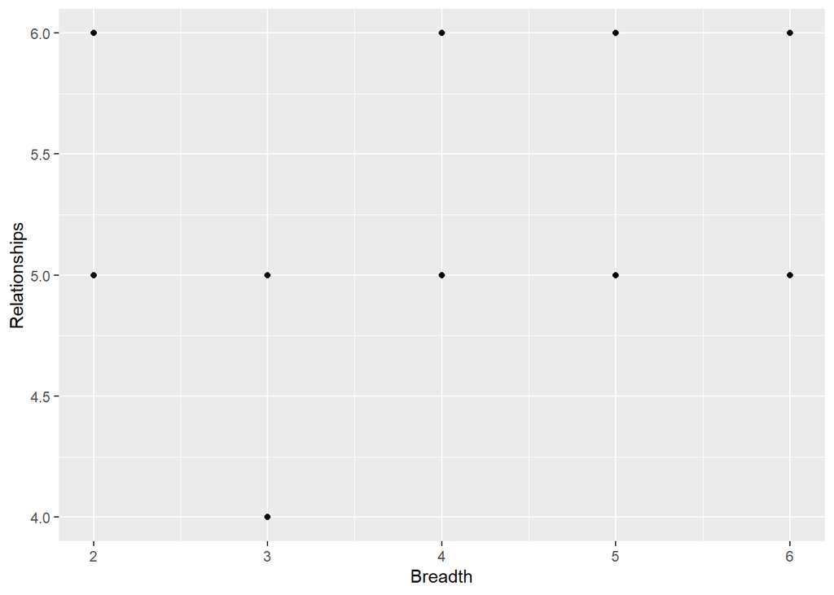

```r
GENERAL %>%
  ggplot(.) +
  geom_point(aes(x = Breadth,
                 y = Relationships))
```

# 8 **Box Plot**

Create a box-plot geom (e.g., `box_plot()`) to plot `Pleasure__1` on the x axis and `Competition` on the y axis.

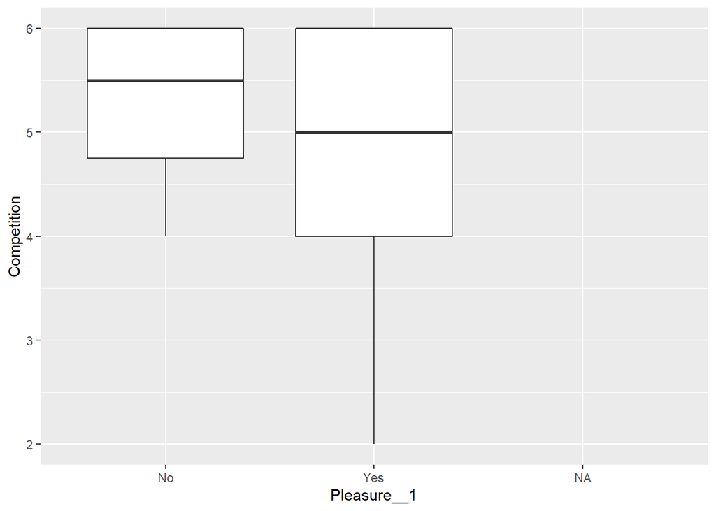

```r
GENERAL %>%
  ggplot(.) +
  geom_boxplot(aes(x = Pleasure__1,
                   y = Competition))
```

# 9 **BONUS CHALLENGE**

Recode all variable names in order to make sense of the data or complete the general survey and cognitive task.

**Upload Submission**: Make sure you have named your file correctly, knit it to html (click icon in RStudio) and upload file [here](https://claremontmckenna.app.box.com/f/80863fd8e0f44ec7a95882d9dda8bb91).

```r
message(paste0("knit by ", usr_time))
```

```
## knit by gcook: sun oct 02 14:56:17 2022
```